# Lesson 5 Example: Apriori algorithm(Titanci)

Let’s work at some dataset. First thing to do is loading the data from `titanic.raw`.

```r
load("~/Desktop/Test/titanic.raw.rdata")
head(titanic.raw)
```

|  | Class | Sex | Age | Survived |
| --- | --- | --- | --- | --- |
| 1 | 3rd | Male | Child | No |
| 2 | 3rd | Male | Child | No |
| 3 | 3rd | Male | Child | No |
| 4 | 3rd | Male | Child | No |
| 5 | 3rd | Male | Child | No |
| 6 | 3rd | Male | Child | No |

Now we can load library and find association rules with default settings. Here we use method `apriori()`.

```r
attach(titanic.raw)
library(Matrix)
library(arules)
library(grid)
library(arulesViz)
```

```r
rules = apriori(titanic.raw)
```

```
Apriori

Parameter specification:
 confidence minval smax arem  aval originalSupport maxtime support minlen maxlen target   ext
        0.8    0.1    1 none FALSE            TRUE       5     0.1      1     10  rules FALSE

Algorithmic control:
 filter tree heap memopt load sort verbose
    0.1 TRUE TRUE  FALSE TRUE    2    TRUE

Absolute minimum support count: 220

set item appearances ...[0 item(s)] done [0.00s].
set transactions ...[10 item(s), 2201 transaction(s)] done [0.00s].
sorting and recoding items ... [9 item(s)] done [0.00s].
creating transaction tree ... done [0.00s].
checking subsets of size 1 2 3 4 done [0.00s].
writing ... [27 rule(s)] done [0.00s].
creating S4 object  ... done [0.00s].
```

```r
inspect(rules)
```

```
     lhs                                   rhs           support   confidence lift
[1]  {}                                 => {Age=Adult}   0.9504771 0.9504771  1.0000000
[2]  {Class=2nd}                        => {Age=Adult}   0.1185825 0.9157895  0.9635051
[3]  {Class=1st}                        => {Age=Adult}   0.1449341 0.9815385  1.0326798
[4]  {Sex=Female}                       => {Age=Adult}   0.1930940 0.9042553  0.9513700
[5]  {Class=3rd}                        => {Age=Adult}   0.2848705 0.8881020  0.9343750
[6]  {Survived=Yes}                     => {Age=Adult}   0.2971377 0.9198312  0.9677574
[7]  {Class=Crew}                       => {Sex=Male}    0.3916402 0.9740113  1.2384742
[8]  {Class=Crew}                       => {Age=Adult}   0.4020900 1.0000000  1.0521033
[9]  {Survived=No}                      => {Sex=Male}    0.6197183 0.9154362  1.1639949
[10] {Survived=No}                      => {Age=Adult}   0.6533394 0.9651007  1.0153856
[11] {Sex=Male}                         => {Age=Adult}   0.7573830 0.9630272  1.0132040
[12] {Sex=Female,Survived=Yes}          => {Age=Adult}   0.1435711 0.9186047  0.9664669
[13] {Class=3rd,Sex=Male}               => {Survived=No} 0.1917310 0.8274510  1.2222950
[14] {Class=3rd,Survived=No}            => {Age=Adult}   0.2162653 0.9015152  0.9484870
[15] {Class=3rd,Sex=Male}               => {Age=Adult}   0.2099046 0.9058824  0.9530818
[16] {Sex=Male,Survived=Yes}            => {Age=Adult}   0.1535666 0.9209809  0.9689670
[17] {Class=Crew,Survived=No}           => {Sex=Male}    0.3044071 0.9955423  1.2658514
[18] {Class=Crew,Survived=No}           => {Age=Adult}   0.3057701 1.0000000  1.0521033
[19] {Class=Crew,Sex=Male}              => {Age=Adult}   0.3916402 1.0000000  1.0521033
[20] {Class=Crew,Age=Adult}             => {Sex=Male}    0.3916402 0.9740113  1.2384742
[21] {Sex=Male,Survived=No}             => {Age=Adult}   0.6038164 0.9743402  1.0251065
[22] {Age=Adult,Survived=No}            => {Sex=Male}    0.6038164 0.9242003  1.1751385
[23] {Class=3rd,Sex=Male,Survived=No}   => {Age=Adult}   0.1758292 0.9170616  0.9648435
[24] {Class=3rd,Age=Adult,Survived=No}  => {Sex=Male}    0.1758292 0.8130252  1.0337773
[25] {Class=3rd,Sex=Male,Age=Adult}     => {Survived=No} 0.1758292 0.8376623  1.2373791
[26] {Class=Crew,Sex=Male,Survived=No}  => {Age=Adult}   0.3044071 1.0000000  1.0521033
[27] {Class=Crew,Age=Adult,Survived=No} => {Sex=Male}    0.3044071 0.9955423  1.2658514
```

##### Breadth-first search

Apriori uses breadth-first search and a tree structure to count candidate item sets efficiently. It generates candidate item sets of length k from item sets of length k-1. Then it prunes the candidates which have an infrequent sub pattern. According to the downward closure lemma, the candidate set contains all frequent k-length item sets. After that, it scans the transaction database to determine frequent item sets among the candidates.

We then set rhs=c(“Survived=No”, “Survived=Yes”) in appearance to make sure that only “Survived=No” and “Survived=Yes” will appear in the rhs of rules. (rules with rhs containing “Survived” only)

```r
rules <- apriori(titanic.raw, parameter = list(minlen=2, supp=0.005, conf=0.8), appearance = list(rhs=c("Survived=No", "Survived=Yes"), default="lhs"), control = list(verbose=F))
rules.sorted <- sort(rules, by="lift")
inspect(rules.sorted)
```

```
     lhs                                  rhs            support     confidence lift
[1]  {Class=2nd,Age=Child}             => {Survived=Yes} 0.010904134 1.0000000  3.095640
[2]  {Class=2nd,Sex=Female,Age=Child}  => {Survived=Yes} 0.005906406 1.0000000  3.095640
[3]  {Class=1st,Sex=Female}            => {Survived=Yes} 0.064061790 0.9724138  3.010243
[4]  {Class=1st,Sex=Female,Age=Adult}  => {Survived=Yes} 0.063607451 0.9722222  3.009650
[5]  {Class=2nd,Sex=Female}            => {Survived=Yes} 0.042253521 0.8773585  2.715986
[6]  {Class=Crew,Sex=Female}           => {Survived=Yes} 0.009086779 0.8695652  2.691861
[7]  {Class=Crew,Sex=Female,Age=Adult} => {Survived=Yes} 0.009086779 0.8695652  2.691861
[8]  {Class=2nd,Sex=Female,Age=Adult}  => {Survived=Yes} 0.036347115 0.8602151  2.662916
[9]  {Class=2nd,Sex=Male,Age=Adult}    => {Survived=No}  0.069968196 0.9166667  1.354083
[10] {Class=2nd,Sex=Male}              => {Survived=No}  0.069968196 0.8603352  1.270871
[11] {Class=3rd,Sex=Male,Age=Adult}    => {Survived=No}  0.175829169 0.8376623  1.237379
[12] {Class=3rd,Sex=Male}              => {Survived=No}  0.191731031 0.8274510  1.222295
```

##### Pruning Redundant Rules

In the above result, rule 2 provides no extra knowledge in addition to rule 1, since rules 1 tells us that all 2nd-class children survived.

Generally speaking, when a rule (such as rule 2) is a super rule of another rule (such as rule 1) and the former has the same or a lower lift, the former rule (rule 2) is considered to be redundant. Below we prune redundant rules.

Let’s find redundant rules now.

```r
subset.matrix <- is.subset(rules.sorted, rules.sorted)
subset.matrix[lower.tri(subset.matrix, diag=T)] <- NA
redundant <- colSums(subset.matrix, na.rm=T) >= 1
which(redundant)
```

```
 {Class=2nd,Sex=Female,Age=Child,Survived=Yes}  {Class=1st,Sex=Female,Age=Adult,Survived=Yes}
                                             2                                              4
{Class=Crew,Sex=Female,Age=Adult,Survived=Yes}  {Class=2nd,Sex=Female,Age=Adult,Survived=Yes}
                                             7                                              8
```

Then we need to remove redundant rules.

```r
rules.pruned <- rules.sorted[!redundant]
inspect(rules.pruned)
```

```
    lhs                               rhs            support     confidence lift
[1] {Class=2nd,Age=Child}          => {Survived=Yes} 0.010904134 1.0000000  3.095640
[2] {Class=1st,Sex=Female}         => {Survived=Yes} 0.064061790 0.9724138  3.010243
[3] {Class=2nd,Sex=Female}         => {Survived=Yes} 0.042253521 0.8773585  2.715986
[4] {Class=Crew,Sex=Female}        => {Survived=Yes} 0.009086779 0.8695652  2.691861
[5] {Class=2nd,Sex=Male,Age=Adult} => {Survived=No}  0.069968196 0.9166667  1.354083
[6] {Class=2nd,Sex=Male}           => {Survived=No}  0.069968196 0.8603352  1.270871
[7] {Class=3rd,Sex=Male,Age=Adult} => {Survived=No}  0.175829169 0.8376623  1.237379
[8] {Class=3rd,Sex=Male}           => {Survived=No}  0.191731031 0.8274510  1.222295
```

Finally, visualizing association rules, there would be 8 rules in the graph.

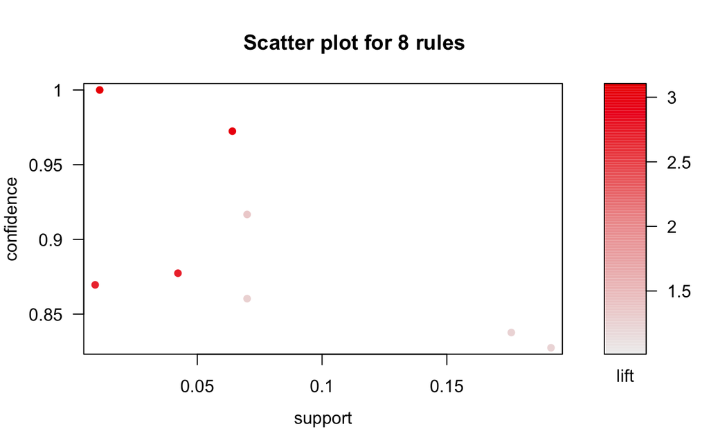

```r
plot(rules.pruned)
```